# Jupyter notebook for *pycoffees* at CAB

Jorge Lillo-Box (Center for Astrobiology) -- 28/september/2023

### Intalling and opening Jupyter notebook

Jupyter comes by default with the Anaconda installation.

But if you would like to install it yourself, a simple installation sentence as the following should work:

`pip install jupyter`

To open an existing Jupyter notebook (*.ipynb) just type the following in your terminal

`jupyter notebook example.ipynb`

To open the file explorer of Jupyter notebook just type:

`jupyter notebook`

### Cell types: code & markdown

There are two (main) types of cells in Jupyter: `code` and `markdown`:

- `code` cells are for python code
- `markdown` cells are for commenting and typing purposes

This is a **Markdown** cell

```python
# This is a commented **code** cell
```

### Cell shortcuts

- **New cells**: You can create new cells above `a` or below `b` the current one.
- **Cell type**: By default, new cells are `code` like. To switch to `markdown` you can press `m` and then press `return` to start typing. To change to a `code` like cell press `y`
- **Delete cell**: `d`+ `d` (double-click on `d`).
- **Moving among cells**: You can move from cell to cell by using the up and down arrows.
- **Running cell**:
  - `Shift` + `Enter` : Run the current cell and move to the next cell.
  - `Ctrl` + `Enter` : Run the current cell and stay.
  - `Alt` + `Enter` : Run the current cell and insert cell below

### Markdown formatting

Have a look at tutorials (like [this one](https://www.earthdatascience.org/courses/intro-to-earth-data-science/file-formats/use-text-files/format-text-with-markdown-jupyter-notebook/)) for extensive information about formatting `markdown` cells.

But basic formatting tips are:

- **Headings**: Use "#" symbol for headings decreasing: `# Title-like heading`, `## Large heading` or `### Smaller heading`
- **Text formatting**: `**bold**`, `_italic_`, `code highlight`, `[blue text linked](url to website)`
- **Bullets**: Use the `*` or `-` symbols to create bullet lists. To nest lists, indent with 4 spaces.
  - Like this!
    - and this!

You can also add LaTeX equations like: \begin{equation} e^x=\sum_{i=0}^\infty \frac{1}{i!}x^i \end{equation} Or even embed it within the text using the `$` symbols like this: $E=mc^2$ (`$E=mc^2$`)

### Code mode

```python
import numpy as np
```

To run a cell just press `Ctrl + Return`

If you want to embed your figures in the notebook, use `%matplotlib inline`

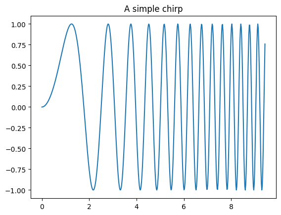

```python
%matplotlib inline

import matplotlib.pyplot as plt
import numpy as np

x = np.linspace(0, 3*np.pi, 500)
plt.plot(x, np.sin(x**2))
plt.title('A simple chirp');
```

If you want to use interactive plotting, you can use modeuls like `bokeh`

```python
from bokeh.plotting import figure, show, output_notebook
import matplotlib.pyplot as plt
output_notebook()
```

Loading BokehJS ...

```python
import plotly.express as px
data = px.data.iris()
```

```python
p = figure()
p.circle(data["sepal_width"], data["sepal_length"], fill_color=data["species"], size=data["sepal_length"])
show(p)
```

[output not shown]